# PS5: markdown and basic plots

Kyra Diaz

2/13/2023

# Instructions

This is a problem set about rmarkdown and plotting (using ggplot). Unlike the previous problem sets, this one does not give you a ready-made GH repo with a code file–it is now your task to create a repo and include your rmarkdown file in there.

You should answer the questions below in that file, knit it, and submit both the compiled html and link to your repo on canvas.

- This problem sets asks you to write extensively when commenting your results. Please write clearly! Answer questions in a way that if the code chunks are hidden then the result is still readable!
  - All substantial questions need explanations. You do not have to explain the simple things like “how many rows are there in data”, but if you make a plot of life expectancy, then you should explain what does the plot tell you.
  - Write explanations as markdown and use the styles like bold and italic as appropriate.
- Do not print too much results. It is all well to print a few lines of data for evaluation/demonstration purposes. But do not print dozens (or thousands!) of lines–no one bothers to look at that many numbers. You will lose points for annoying others (here your graders, but later potentially your boss).
- Do not make code lines too long. 80-100 characters is a good choice. Your grader may not be able to follow all the code if the line is too long–most of us are using small laptop screens! (And again–you want to keep your graders happy!)

# Gapminder data

We use gapminder dataset, downloaded from [**https://www.gapminder.org/data/**](https://www.gapminder.org/data/), however, the data structure there is quire complex, please use the dataset provided on canvas (in files/data).  
The variables are:  
**name** country name  
**iso3** 3-letter country code  
**iso2** 2-letter country code  
**region** broad geographic region  
**sub-region** more precise region  
**intermediate-region**  
**time** year  
**totalPopulation** total population  
**GDP_PC** GDP per capita (constant 2010 US$)  
**accessElectricity** Access to electricity (% of population)  
**agriculturalLand** Agricultural land (sq. km)  
**agricultureTractors** Agricultural machinery, tractors (count)  
**cerealProduction** Cereal production (metric tons)  
**feritilizerHa** Fertilizer consumption (kilograms per hectare of arable land)  
**fertilityRate** total fertility rate (births per woman)  
**lifeExpectancy** Life expectancy at birth, total (years)  
**childMortality** Mortality rate, under-5 (per 1,000 live births)  
**youthFemaleLiteracy** Literacy rate, youth female (% of females ages 15-24)  
**youthMaleLiteracy** Literacy rate, youth male (% of males ages 15-24)  
**adultLiteracy** Literacy rate, adult total (% of people ages 15 and above)  
**co2** CO2 emissions (kt)  
**greenhouseGases** Total greenhouse gas emissions (kt of CO2 equivalent)  
**co2_PC** CO2 emissions (metric tons per capita)  
**pm2.5_35** PM2.5 pollution, population exposed to levels exceeding WHO Interim Target-1 value 36ug/m3  
**battleDeaths** Battle-related deaths (number of people)

# Load and check data (5pt)

You first task is to do a very simple data check:

**1. (1pt) For solving the problems, and answering the questions, create a new rmarkdown document with an appropriate title. See [**https://faculty.washington.edu/otoomet/info201-book/r-markdown.html#r-markdown-rstudio-creating**](https://faculty.washington.edu/otoomet/info201-book/r-markdown.html#r-markdown-rstudio-creating).**

**2. (2pt) Load data. How many rows/columns do we have?**

```r
library(tidyverse)

gap <- read_delim("gapminder.csv.bz2")

nrow(gap)
```

```
## [1] 13055
```

```r
ncol(gap)
```

```
## [1] 25
```

The *Gapminder* dataset has 13055 rows and 25 columns.

**3. (2pt) Print a small sample of data. Does it look OK?**

Here’s a sample of the data:

```r
gap %>%
  sample_n(5)
```

```
## # A tibble: 5 × 25
##   iso3  name  iso2  region sub-r…¹ inter…²  time total…³ ferti…⁴ lifeE…⁵ child…⁶
##   <chr> <chr> <chr> <chr>  <chr>   <chr>   <dbl>   <dbl>   <dbl>   <dbl>   <dbl>
## 1 SGP   Sing… SG    Asia   South-… <NA>     2017  5.61e6    1.16    83.1     2.7
## 2 BRB   Barb… BB    Ameri… Latin … Caribb…  1978  2.50e5    2.12    71.4    30.4
## 3 GEO   Geor… GE    Asia   Wester… <NA>     1968  4.04e6    2.78    66.8    NA
## 4 KOS   <NA>  <NA>  <NA>   <NA>    <NA>     2015  1.79e6    2.09    71.5    NA
## 5 VNM   Viet… VN    Asia   South-… <NA>     1960  3.27e7    6.35    59.0    NA
## # … with 14 more variables: youthFemaleLiteracy <dbl>, youthMaleLiteracy <dbl>,
## #   adultLiteracy <dbl>, GDP_PC <dbl>, accessElectricity <dbl>,
## #   agriculturalLand <dbl>, agricultureTractors <dbl>, cerealProduction <dbl>,
## #   fertilizerHa <dbl>, co2 <dbl>, greenhouseGases <dbl>, co2_PC <dbl>,
## #   pm2.5_35 <dbl>, battleDeaths <dbl>, and abbreviated variable names
## #   ¹`sub-region`, ²`intermediate-region`, ³totalPopulation, ⁴fertilityRate,
## #   ⁵lifeExpectancy, ⁶childMortality
```

It looks good!

# Descriptive statistics (15pt)

**1. (3pt) How many countries are there in the dataset? Analyze all three: *iso3*, *iso2* and *name*.**

```r
gap %>%
  summarize(countries = n_distinct(name),
            n_iso2 = n_distinct(iso2),
            n_iso3 = n_distinct(iso3))
```

```
## # A tibble: 1 × 3
##   countries n_iso2 n_iso3
##       <int>  <int>  <int>
## 1       250    249    253
```

There seems to be 250 countries, 249 iso-2 codes, and 253 iso-3 country codes.

**2. If you did this correctly, you saw that there are more iso-2 codes than names, and there are even more *iso3*-codes. What is going on? Can you find it out?**

**(a) (5pt) Find how many names are there for each iso-2 code. Are there any iso-2 codes that correspond to more than one name? What are these countries?**

```r
gap %>%
  group_by(name) %>%
  summarize(iso2_countries = n_distinct(iso2)) %>%
  arrange(desc(iso2_countries))
```

```
## # A tibble: 250 × 2
##    name                iso2_countries
##    <chr>                        <int>
##  1 Afghanistan                      1
##  2 Albania                          1
##  3 Algeria                          1
##  4 American Samoa                   1
##  5 Andorra                          1
##  6 Angola                           1
##  7 Anguilla                         1
##  8 Antarctica                       1
##  9 Antigua and Barbuda              1
## 10 Argentina                        1
## # … with 240 more rows
```

There are no iso-2 codes that correspond to more than one country.

**(b) (5pt) Now repeat the same for name and iso3-code. Are there country names that have more than one iso3-code? What are these countries? Hint: two of these entitites are *CHANISL* and *NLD CURACAO*.**

```r
gap %>%
  group_by(name) %>%
  summarize(iso3_countries = n_distinct(iso3)) %>%
  arrange(desc(iso3_countries))
```

```
## # A tibble: 250 × 2
##    name                iso3_countries
##    <chr>                        <int>
##  1 <NA>                             4
##  2 Afghanistan                      1
##  3 Albania                          1
##  4 Algeria                          1
##  5 American Samoa                   1
##  6 Andorra                          1
##  7 Angola                           1
##  8 Anguilla                         1
##  9 Antarctica                       1
## 10 Antigua and Barbuda              1
## # … with 240 more rows
```

It seems that there are four iso3 codes that do not have a country assigned to them (instead, they’re labeled “NA”). We can check which iso3 codes these are by doing the following:

```r
gap %>%
  filter(is.na(name)) %>%
  group_by(name) %>%
  distinct(iso3)
```

```
## # A tibble: 4 × 2
## # Groups:   name [1]
##   name  iso3
##   <chr> <chr>
## 1 <NA>  CHANISL
## 2 <NA>  GBM
## 3 <NA>  KOS
## 4 <NA>  NLD_CURACAO
```

According to the code, the iso3 codes with no country include CHANISL, GBM, KOS, and NLD_CURACAO.

**3. (2pt) What is the minimum and maximum year in these data?**

```r
min_yr <- gap %>%
  select(time) %>%
  filter(!is.na(time)) %>%
  min()

min_yr
```

```
## [1] 1960
```

```r
max_yr <- gap %>%
  select(time) %>%
  filter(!is.na(time)) %>%
  max()

max_yr
```

```
## [1] 2019
```

The minimum year is 1960 and the maximum year is 2019.

# CO2 emissions (30pt)

Next, let’s analyze CO2 emissions.

**1. (2pt) How many missing co2 emissions are there for each year? Analyze both missing *CO2* and *co2_PC*. Which years have most missing data?**

```r
 gap %>%
  select(time, co2, co2_PC) %>%
  group_by(time) %>%
  filter(is.na(co2_PC), is.na(co2)) %>%
  count() %>%
  arrange(desc(n))
```

```
## # A tibble: 61 × 2
## # Groups:   time [61]
##     time     n
##    <dbl> <int>
##  1  2017   217
##  2  2018   217
##  3  2019   217
##  4  1960    60
##  5  1961    60
##  6  1962    58
##  7  1963    57
##  8  1964    51
##  9  1965    51
## 10  1966    51
## # … with 51 more rows
```

2017, 2018, and 2019 have the most missing co2 emissions with a frequency of 217.

**2. (5pt) Make a plot of total CO2 emissions over time for the U.S, China, and India. Add a few more countries of your choice. Explain what do you see.**

First, I made a subset with the countries I wanted to plot:

```r
co2_countries <- c("China", "United States of America", "India", "Philippines", "Mexico", "France")

co2_gap <- gap %>%
  filter(name == co2_countries) %>% #error with this line
  filter(!is.na(co2))
```

Then, I plotted these points:

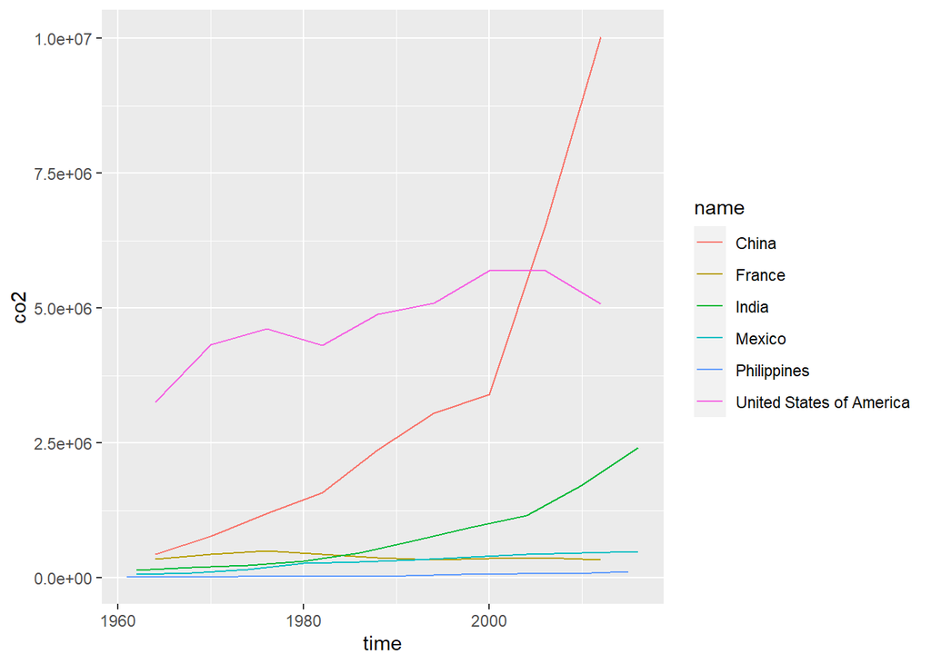

```r
ggplot(co2_gap) +
  geom_line(aes(x = time, y = co2,
                group = name,
                color = name))
```

Looking at the data, we can see clearly that China’s CO2 emissions have increased a lot more than other countries over time. In addition, the U.S. seems to have higher levels of CO2 emissions overall, though hasn’t increased as much as China. India also has upward trends of CO2 emissions, but Mexico, Philippines, and France have remained pretty constant.

**3. (5pt) Now let’s analyze the CO2 emissions per capita (*co2_PC*). Make a similar plot of the same countries. What does this figure suggest?**

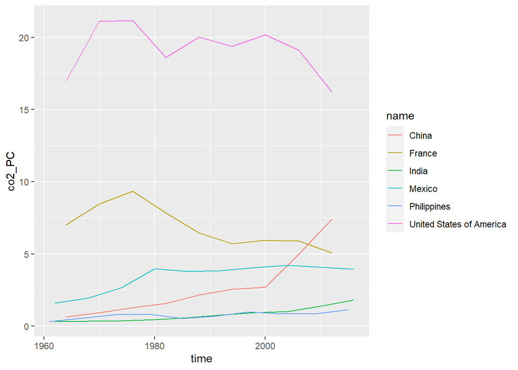

```r
ggplot(co2_gap) +
  geom_line(aes(x = time, y = co2_PC,
                group = name,
                color = name))
```

Overall,the U.S. has a higher rate of CO2 emissions per capita France, Mexico, China, Philippines, and India.

**4. (6pt) Compute average CO2 emissions per capita across the continents (assume *region* is the same as continent). Comment what do you see.**  
**Note: just compute averages over countries and ignore the fact that countries are of different size.**  
**Hint: Americas 2016 should be 4.80.**

```r
co2_regions <- gap %>%
  group_by(time, region) %>%
  filter(!is.na(co2_PC), !is.na(region)) %>%
  mutate(avg_co2PC = mean(co2_PC)) %>%
  select(region, time, avg_co2PC) %>%
  arrange(desc(time))

head(co2_regions, 8)
```

```
## # A tibble: 8 × 3
## # Groups:   time, region [4]
##   region    time avg_co2PC
##   <chr>    <dbl>     <dbl>
## 1 Americas  2016      4.80
## 2 Asia      2016      6.47
## 3 Africa    2016      1.20
## 4 Europe    2016      6.64
## 5 Europe    2016      6.64
## 6 Asia      2016      6.47
## 7 Americas  2016      4.80
## 8 Asia      2016      6.47
```

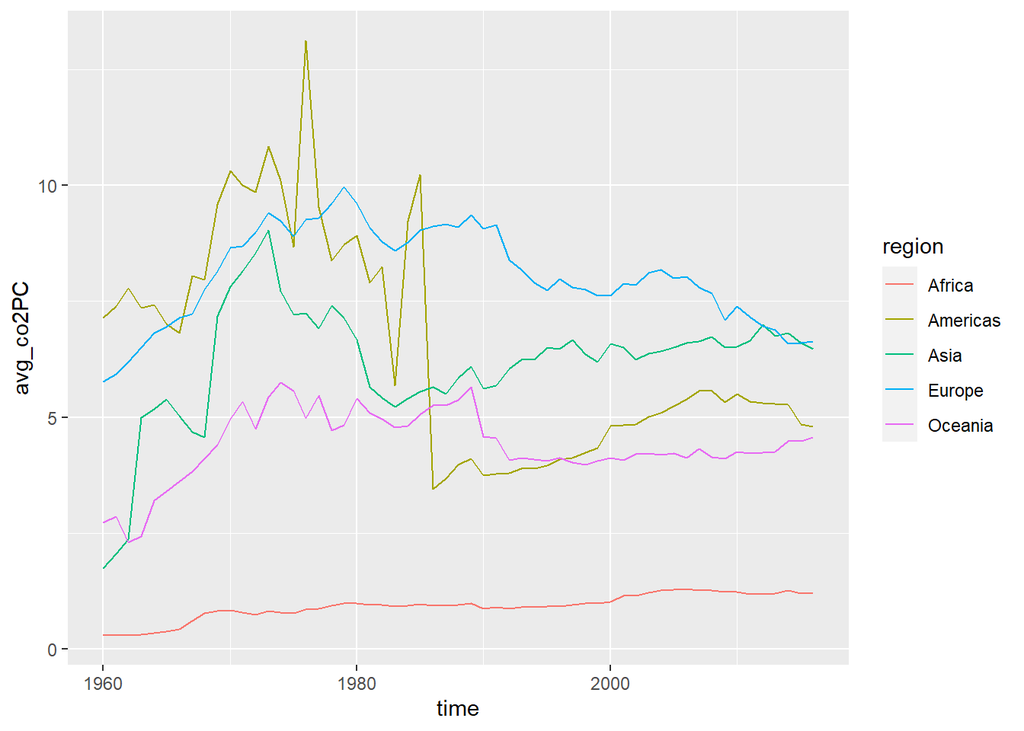

```r
ggplot(co2_regions) +
  geom_line(aes(x = time, y = avg_co2PC,
                group = region,
                color = region))
```

```r
gap %>%
  filter(time == 2016, !is.na(co2_PC), !is.na(region)) %>%
  group_by(region) %>%
  summarize(avg_co2PC = mean(co2_PC))
```

```
## # A tibble: 5 × 2
##   region   avg_co2PC
##   <chr>        <dbl>
## 1 Africa        1.20
## 2 Americas      4.80
## 3 Asia          6.47
## 4 Europe        6.64
## 5 Oceania       4.57
```

# GDP per capita (50pt)

Let’s look at GDP per capita (*GDP_PC*)

1. (8pt) Make a scatterplot of GDP per capita versus life expectancy by country, using data for 1960. Make the point size dependent on the country size, and color those according to the continent. Feel free to adjust the plot in other ways to make it better.  
   Comment what do you see there.
2. (4pt) Make a similar plot, but this time use 2019 data only.
3. (6pt) Compare these two plots and comment what do you see. How has world developed through the last 60 years?
4. (6pt) Compute the average life expectancy for each continent in 1960 and 2019. Do the results fit with what do you see on the figures?  
   Note: here as *average*I mean just average over countries, ignore the fact that countries are of different size.
5. (8pt) Compute the average LE growth from 1960-2019 across the continents. Show the results in the order of growth. Explain what do you see.  
   Hint: these data (data in long form) is not the simplest to compute growth. But you may want to check out the lag() function. And do not forget to group data by continent when using lag(), otherwise your results will be messed up! See [**https://faculty.washington.edu/otoomet/info201-book/dplyr.html#dplyr-helpers-compute**](https://faculty.washington.edu/otoomet/info201-book/dplyr.html#dplyr-helpers-compute).
6. (6pt) Show the histogram of GDP per capita for years of 1960 and 2019. Try to put both histograms on the same graph, see how well you can do it!
7. (6pt) What was the ranking of US in terms of life expectancy in 1960 and in 2019? (When counting from top.)  
   Hint: check out the function rank()!  
   Hint2: 17 for 1960.
8. (6pt) If you did this correctly, then you noticed that US ranking has been falling quite a bit. But we also have more countries in 2019–what about the relative rank divided by the corresponding number of countries that have LE data in the corresponding year?  
   Hint: 0.0904 for 1960.

Finally tell us how many hours did you spend on this PS.